# Advanced Rmarkdown

Jan 28, 2026

## Some - semi-advanced R Markdown

Awesome (free) resource: https://bookdown.org/yihui/rmarkdown/

## YAML

## What is YAML?

**Y**AML **A**in’t **M**arkup **L**anguage

- Header block at top of `.Rmd`
- Enclosed by `---`
- Controls document metadata & output
- Key-value pairs with colons

```yaml
---
title: My Document
author: Me
output: html_document
---
```

## Pieces of a YAML

**Basic metadata**

```yaml
---
title: "My Analysis"
subtitle: "A deeper dive"
author: "Dr. Gurarie"
date: "January 28, 2026"
output: html_document
---
```

**Key rules**

- Indentation matters (2 spaces)
- Quotes optional for simple strings
- Nested options indented below parent

## Output Types

**Documents**

```yaml
output: html_document
output: pdf_document
output: word_document
```

**Presentations**

```yaml
output: ioslides_presentation
output: slidy_presentation
output: beamer_presentation
```

Note: `pdf_document` and `beamer_presentation` require LaTeX

## Table of Contents

## Nested Output Options

```yaml
output:
  html_document:
    toc: true
    toc_float: true
    theme: flatly
    code_folding: hide
    fig_width: 8
    fig_height: 6
```

Each output type has its own set of sub-options — check the documentation!

## Using R Code *in* YAML

**Dynamic date**

```yaml
date: "`r Sys.Date()`"
```

outputs:

```yaml
date: "2026-01-26"
```

**Or Dynamic anything!**

```yaml
author: "`r paste(LETTERS[c(8,25,1,20,20)], collapse = "")`"
date: "`r Sys.Date()`"
```

outputs:

```yaml
author: "HYATT"
date: "2026-01-26"
```

## Fancy Themes

`install.packages("rmdformats")`

```yaml
output:
  rmdformats::readthedown
```

```yaml
output:
  rmdformats::material
```

```yaml
output:
  rmdformats::downcute
```

Check out gallery: github.com/juba/rmdformats

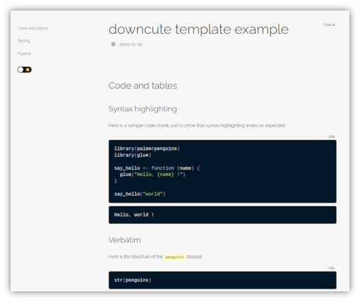

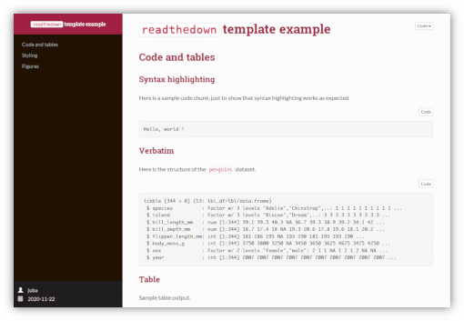

## Prettydoc

`install.packages("prettydoc")`

```yaml
output:
  prettydoc::html_pretty:
    theme: cayman
```

**Themes available:**

- `cayman`
- `tactile`
- `architect`
- `leonids`
- `hpstr`

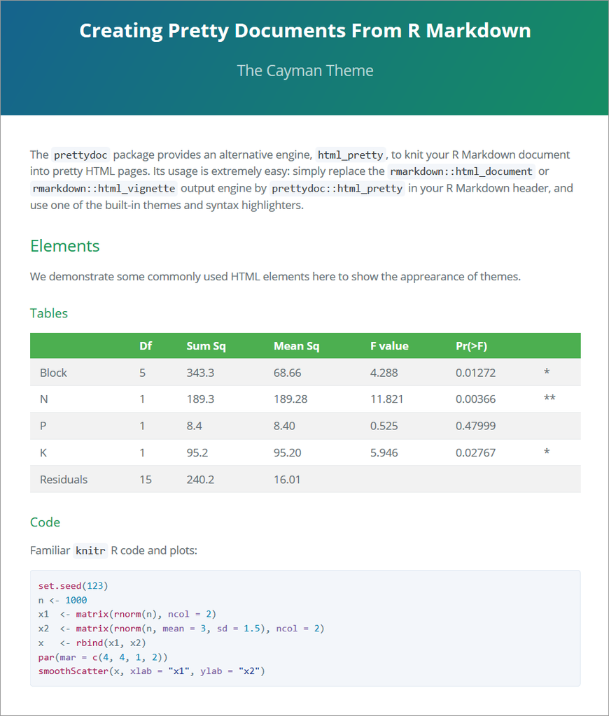

https://prettydoc.statr.me/themes.html

## Presentation Packages

| Package | Output | Notes |
| --- | --- | --- |
| `ioslides` | HTML slides | Built-in, simple |
| `xaringan` | HTML slides | Highly customizable, remark.js |
| `revealjs` | HTML slides | 3D transitions |
| `beamer` | PDF slides | LaTeX-based |

## YAML for `xaringan`

For example: [**Lecture: How to Model Anything**](https://eligurarie.github.io/EFB390/lectures/Lecture10/Lecture_Modeling_PartII.html#1)

```yaml
---
title: "How to model just about anything<br>(but especially habitat) Part II"
subtitle: "EFB 390: Wildlife Ecology and Management"
author: "Dr. Elie Gurarie"
date: "October 3, 2024"
output:
  xaringan::moon_reader:
    css: [default, default-fonts, mycss.css]
    nature:
      highlightStyle: github
      countIncrementalSlides: false
      highlightLines: true
      titleSlideClass: ["center","middle","white"]
      ratio: '16:9'
editor_options:
  chunk_output_type: console
---
```

## Chunks

## What is a Chunk?

**Input:**

````
```{r}
mean(c(1, 2, 3))
```
````

**Output:**

```r
mean(c(1, 2, 3))
```

```
## [1] 2
```

## Naming Chunks

````
```{r my-summary-stats}
summary(iris)
```
````

**Why name chunks?**

- Easier debugging (error messages reference name)
- Required for cached chunks & cross-references
- Navigation in RStudio outline pane

Rules: no spaces, no underscores (use `-`)

## `eval`: Run the Code?

**Input:**

````
```{r eval=FALSE}
2 + 2
```

```{r eval=2}
2 + 2
cat("Dr. Green Teach Good")
```
````

**Output:**

```r
2 + 2
```

*(code shown, not executed)*

```r
## 2 + 2
cat("Dr. Green Teach Good")
```

```
## Dr. Green Teach Good
```

*only line 2 evaluated*

## `echo`: Show the Code?

**Input:**

````
```{r echo=FALSE}
2 + 2
```

```{r echo=-2}
2 + 2
cat("Dr. Green Teach Good")
```
````

**Output:**

```
## [1] 4
```

*output only, code hidden*

```r
2 + 2
```

```
## [1] 4
```

```
## Dr. Green Teach Good
```

*don’t show the second line of code - just the output*

## `eval` + `echo` Combinations

| `eval` | `echo` | Result |
| --- | --- | --- |
| TRUE | TRUE | Code + Output |
| TRUE | FALSE | Output only |
| FALSE | TRUE | Code only (display) |
| FALSE | FALSE | Nothing! |

## Figure Options: Default

**Input:**

````
```{r}
k <- 10
x <- seq(-1,1,length = 1000)
M <- sapply(k:1, function(f)
  cos(x*f * pi) * sqrt(1 - x^2))
matplot(x, M, type = "l", col = 1:k,
        lty = 1, lwd = seq(1,3,length = k))
```
````

**Output:**

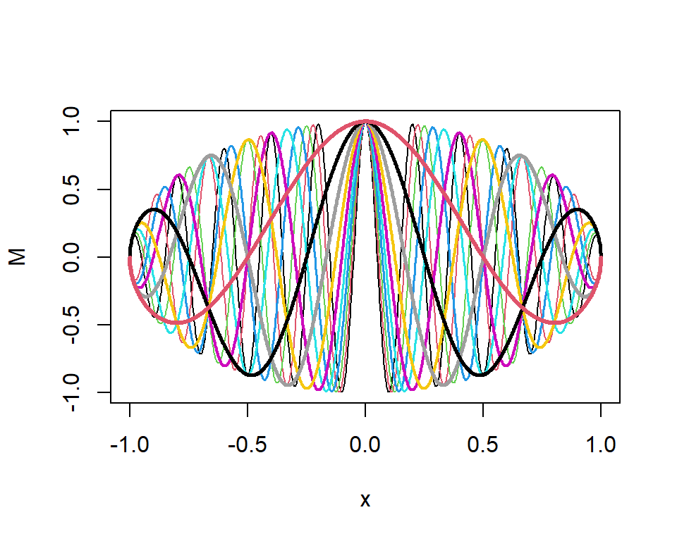